# LLM-ek programozott használata kutatási célra

Tamási Árpád · ELTE TáTK

5. óra — 2026. október 12.

# A tábla

## Kódolócsoport

[figure not shown]

A kézi kör a gépi eredmény ismerete nélkül készül.

## Korpuszcsoport

[figure not shown]

Ha harmincból három releváns, a keresés a hiba, nem a gép.

## Adatbázis-csoport

[figure not shown]

Az üres mező az adatmodell hibája, az eltérés a gépé.

## Szakirodalmi csoport

[figure not shown]

Amit a keresés nem hoz vissza, azt a szűrés soha nem vonja be.

# Git

## Minden *verzió* visszahozható

[figure not shown]

- Minden verzió megmarad, dátummal és egy mondattal, és bármelyikhez vissza lehet menni. Nem kell `vegleges_v3_JAVITOTT.docx`.

„Elrontottam” helyett: „hozd vissza a tegnapi változatot”.

## A *commit* egy verzió, és megmondja, miért

- A **commit** egy verzió, egy rövid üzenettel: mit és miért
- Az üzenetekből áll össze a projekted naplója
- Commit előtt nézd meg a **diffet**: pirossal, ami kikerült, zölddel, ami bekerült

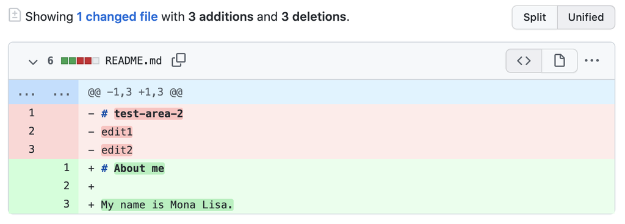

Az ügynökkel ez a legfontosabb mozdulat: megnézni, mit írt át, mielőtt elfogadod.

## A *GitHub*: ugyanez a sor, közös polcon

[figure not shown]

- **Nyilvános vagy privát:** ki látja a kódot és a teljes történetét — döntés, nem alapbeállítás
- Belépés kell hozzá; ha 403-at kapsz, a GitHub nem tudja, ki vagy, vagy nincs jogod a repóhoz

## *Push* és *pull*: ami nincs fent, azt senki nem látja

- **push:** a gépeden lévő commitok fel a GitHubra
- **pull:** ami a GitHubon újabb, le a gépedre — **munka előtt**
- A „mentsd el” csak a gépedig visz; a Claude-nak: *„commit és push”*

A munka megvan, de amíg nincs fent, nem látszik.

## Új gépen: *clone*

- A **clone** a teljes repót lehozza egy új gépre, a teljes történettel együtt
- Egyetemi gép, otthoni gép, egy kolléga gépe: mindegyiken ugyanaz a projekt
- Utána ugyanúgy pull, commit, push

## Ha két helyen ugyanazt írták át: *ütközés*

- Két gépen, vagy te és a Claude, ugyanazt a sort másképp
- A git nem dönt helyetted: megmutatja mindkét változatot
- Kérd a Claude-ot, hogy oldja fel — de nézd meg, melyiket tartotta meg

## *Mi menjen fel*: a recept, nem a nyersanyag

#### Felmegy

- a kód, a promptok, a kódkönyv
- a README, a döntési napló
- kis, megosztható mintaadat

#### Nem megy fel

- letöltött szövegek, személyes adat
- API-kulcs, jelszó
- nagy fájlok (a GitHub 100 MB fölött nem is fogadja)

## A *.gitignore*: amit a git nem lát

```
data/
.env
*.sav
```

- Egy fájl a repó gyökerében: ami benne van, azt a git nem menti és nem viszi fel
- Ami **egyszer felment**, az a történetben marad — a törlés nem elég
- A Claude-nak: *„Tedd a data mappát és a .env-et a .gitignore-ba.”*

Előbb a .gitignore, aztán a letöltés — nem fordítva.

## *Hat mondat* a Claude-nak

| Helyzet | Mondat |
| --- | --- |
| munka előtt | *„Húzd le a legfrissebb változatot.”* |
| mit csinált | *„Mit változtattál? Mutasd a diffet.”* |
| munka után | *„Commit és push, üzenettel: mit és miért.”* |
| elrontottad | *„Hozd vissza a tegnapi változatát.”* |
| új gépen | *„Klónozd le ezt a repót.”* |
| adat jön | *„Tedd a data mappát a .gitignore-ba.”* |

# Hogyan dolgozik a Claude

## A modell *szöveget folytat*

[figure not shown]

- Minden lépésben esélyt ad a következő szóra, **húz** egyet, hozzáfűzi, és újra
- Ugyanabból a kezdetből két futtatás két különböző mondathoz jut

Amit a modell tud a projektedről, azt mind ott kapja meg, abban a pillanatban.

## A *kontextus*: minden, amit lát

- Ami ebben nincs benne, azt **nem tudja**, legfeljebb kitalálja

A kontextus véges: egy hosszú munkamenet végén az eleje elhalványul.

## Az *AGENTS.md*: amit minden reggel az asztalán talál

- Egy fájl a repó gyökerében, ami **minden munkamenet elején** bekerül a kontextusba
- Ide jön, amit mindig tudnia kell: mi a projekt, mik a szabályok, mit döntöttél már
- Ha valamit kétszer elmondtál neki, az ide való

A Claude Code a CLAUDE.md-t olvassa; nálunk az csak annyit mond: olvasd az AGENTS.md-t.

## A *toolok*: kéz a modellnek

[figure not shown]

- A modell nem nyúl semmihez: **leírja szövegben**, mit kér, a Claude Code végrehajtja
- Az eredmény is szövegként kerül vissza a kontextusba, és jön a következő lépés: körbe, amíg kész nincs

## A *fájlok*: csak azt látja, amit beolvasott

- Olvas, ír, szerkeszt — mindegyik egy-egy tool, egy-egy lépés
- Amit nem olvasott be, arról **nem tud**, csak a nevéből találgat
- Amit átírt, azt a diffben látod — ezért nézzük meg commit előtt

„Olvasd be a kódkönyvet, és csak utána javasolj” — jobb, mint „javíts a kódkönyvön”.

## A *parancsok*: amit a terminálban futtat

- `git`, `python`, `pip` — minden, amit a terminálban lehet, neki is tool
- A „commit és push” is két parancs, amit ő futtat helyetted
- Ezért **kér engedélyt**: egy parancs bármit megtehet a gépeden

Az engedélykérést olvasd el, mielőtt rábólintasz: ott látszik, mit akar csinálni.

## Ebből *mi következik neked*

| Ha … | akkor |
| --- | --- |
| mindig el kell mondanod valamit | írd az AGENTS.md-be |
| rossz fájlról beszél | mondd meg, mit olvasson be |
| hosszú lett a munkamenet | írasd le, hol tartotok, és nyiss újat |
| engedélyt kér | olvasd el, mit akar futtatni |
| kétszer mást mond | nem hiba: egy válasz egy húzás |